# Rosalina Delwiche’s Analysis

Rosalina Delwiche

September 30, 2022

## Making bar plot for number of passengers per month coming from LGA for each year (2017, 2018, 2019, 2020, 2021, 2022)

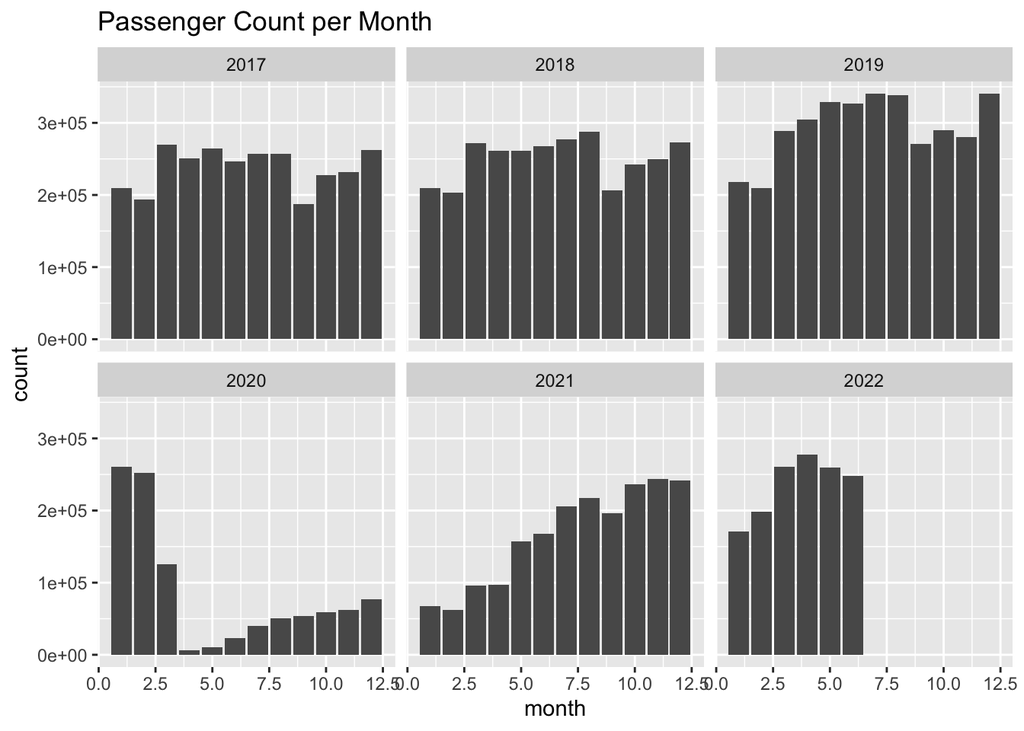

```r
# creating a faceted bar plot that has the number of passengers per month for each
df_all %>% ggplot(aes(month)) + geom_bar(aes(weight=passengers)) + ggtitle("Passenger Count per Month") + facet_wrap(~year)
```

## Making Bar Plot and Point Graph with Trendline to visualize

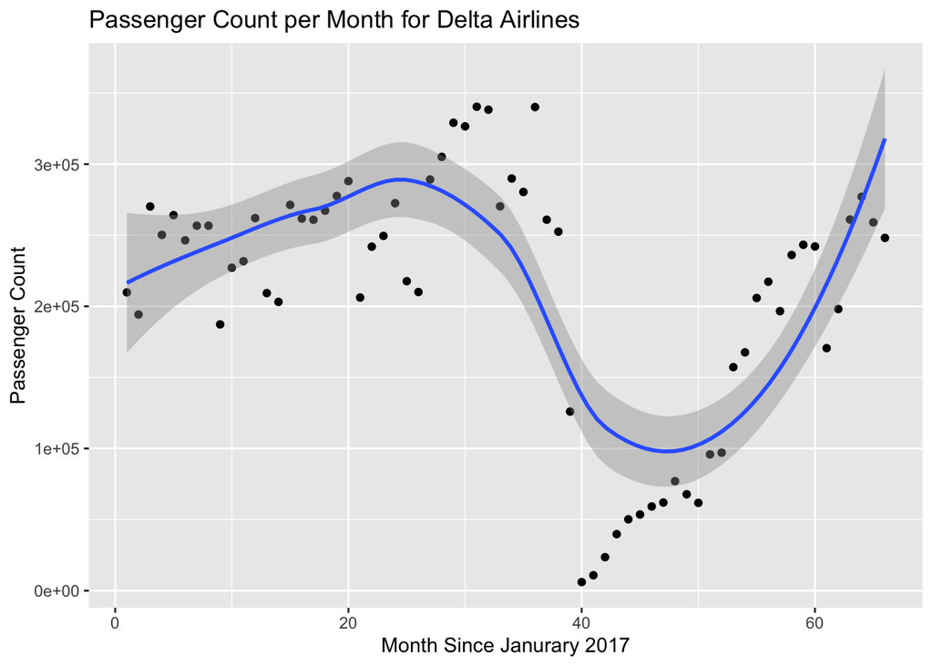

```r
# df_count_summary contains 66 observations - one per month with the total number of passengers
df_count_summary = df_all_new %>% group_by(year_month) %>% summarize(count = sum(passengers)) %>%  ungroup() %>% mutate(month_num=c(1:66))


# Visual 1: Creating a scatter plot with count of passengers per MM/YYYY with trend line
df_count_summary %>% ggplot(aes(month_num, count)) + geom_point()  + geom_smooth(method = "auto") +ggtitle("Passenger Count per Month for Delta Airlines") +  xlab("Month Since Janurary 2017") + ylab("Passenger Count")
```

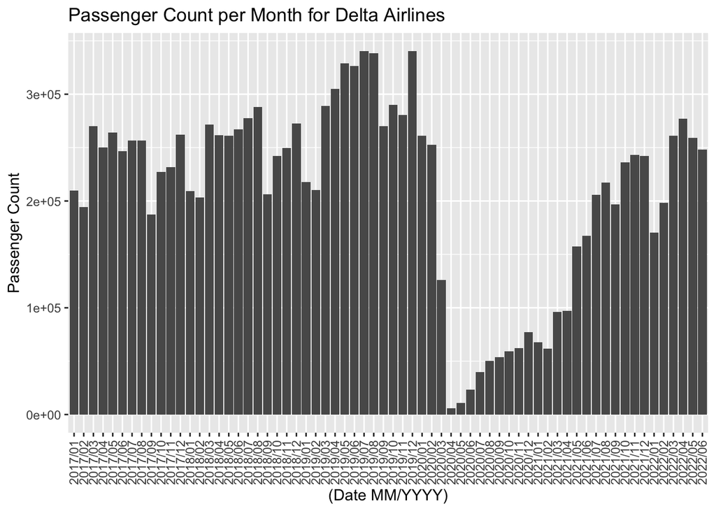

```r
# Visual 2: Creating a bar plot with count of passengers per MM/YYYY
df_all_new %>% ggplot(aes(year_month)) + geom_bar(aes(weight=passengers)) +  ggtitle("Passenger Count per Month for Delta Airlines") + theme(axis.text.x = element_text(angle = 90, vjust = 0.5, hjust=1)) + xlab("(Date MM/YYYY)")  + ylab("Passenger Count")
```

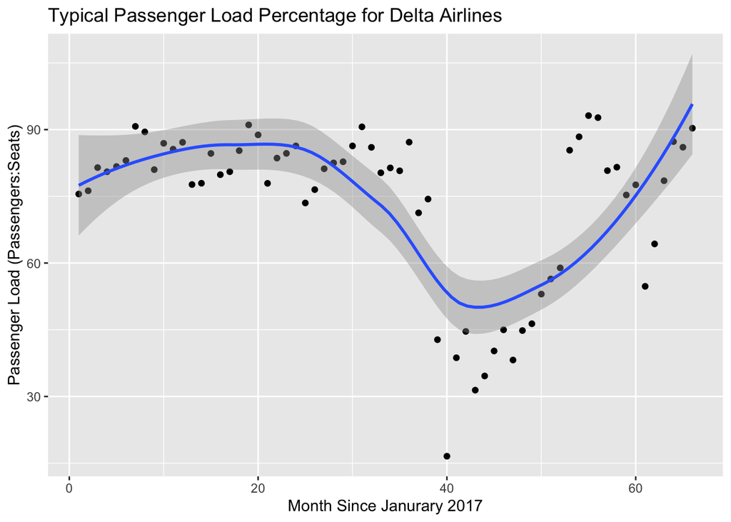

```r
# df_all_new_3 contains 66 observations - one per month with the total load as defined by the number of passengers divided by seats
df_all_new_3 = df_all_new %>% group_by(year_month) %>%  summarise(passenger_total = sum(passengers), seat_total = sum(seats)) %>% mutate(load = (passenger_total/seat_total)*100 ) %>% mutate(month_num=c(1:66))

# Visual 3: Creating a scatter plot with count of passengers per MM/YYYY with trend line
df_all_new_3 %>% ggplot(aes(month_num, load)) + geom_point()  + geom_smooth(method = "auto") +ggtitle("Typical Passenger Load Percentage for Delta Airlines") +  xlab("Month Since Janurary 2017") + ylab("Passenger Load (Passengers:Seats)")
```

## Analysis

I have chosen to make a variety of visual representations. The bar plot provides insight to the quanitity of passengers, but it is harder to tell the trend. Thus, I made scatterplot with a trendline for the number of passengers per month. This clearly displays the upwards trend in passengers. Further, the scatterplot with the trend of the percentage of passengers to seats provides insight that a higher capacity nowadays is being reached. It is already known that flights are scheduled months in advanced so the number of seats is known beforehand. It is the number of passengers that remains unknown prior to the flight. Using a trend line it may be possible to multiply the expected value from the graph of (passengers/seats) by the number of known seats to get the number of passengers. With all representations it is clear that the number of passengers with increase from the last couple of months. The degree of increase is the question.